# MUSIC OF THE AGES

By : Prashant Shrivastava • Applied Math • National Institute of Technology, Surat

#### STYLING CONFIGS

```python
%%html
<style type='text/css'>
.CodeMirror{
    font-size: 15px;
    font-family: Jetbrains Mono;
}

</style>
```

#### INTRODUCTION

In this Analysis we are going to take a deep dive into the Music of all arround the world, from the 50s to the modern 2019. From Michael Jackson to The Weeknd, from The Beatles to Queen, we are going to analyze Music from all arroud the world since the last 69 Years and answer questions based on the results we do obtain. So let's get started with getting in touch with the Databases we're going to work with in this Analysis Report.

#### PACKAGE IMPORTS

```python
import pandas as pd
import numpy as np
import matplotlib.pyplot as plt
import seaborn as sns
import string
import warnings
```

#### DATASET IMPORTS & MATPLOTLIB CONFIGS

```python
main_music = pd.read_csv('working_data/biGmusic.csv')
top500 = pd.read_csv('working_data/top500songs.csv', encoding = 'latin-1')
plt.style.use('fivethirtyeight')
%matplotlib inline
main_music.set_index('serial', inplace = True)
warnings.filterwarnings('ignore')
```

The following part of this Notebook is divided into segments, each one have their own topic/theme, discussing and analyzing different parts of the datasets and answering questions on the way based on the results obtained from the dataset, starting with segement 1

### HOW DO DIFFERENT RATINGS RELATE TO THEMSELVES?

#### Let's Talk About The Overall Heatmap

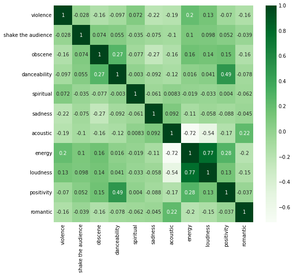

```python
heatmap = main_music.loc[:, 'violence':'romantic'].copy(deep = True)
heatmap.pop('topic')

heatmatrix = heatmap.corr()
plt.figure(figsize = (8, 8))
sns.heatmap(heatmatrix, annot = True, cmap = 'Greens')
plt.show()
```

## SEGMENT - 1

### Topic : Past & The Present

#### Questions & Topics to be discussed :

1. Which Era of Music produced the most romantic songs?
2. Is Today's Music more Negative than the average?
3. Were the 60s more romantic than today?
4. Is today's music more violent and obscene than 50-60s?
5. Which Genration's Music had the most Crowd Involvement / STA Rating?
6. Search for the most Spiritual & Positive Music Genration.
7. Is today's music more louder than yesterday's?
8. Analysis of Sadness in Modern Music.

### 1. WHICH ERA OF MUSIC PRODUCED THE MOST ROMANTIC SONGS?

(Estimator Used : Mean)

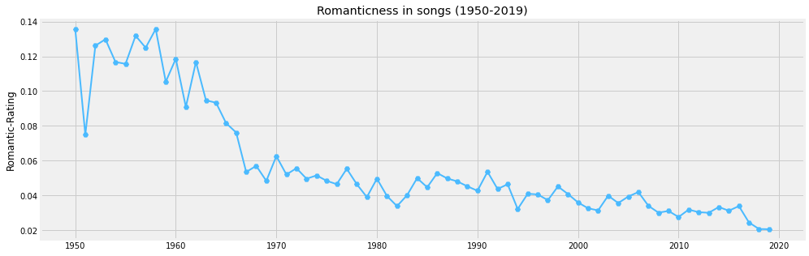

```python
years_rom = main_music.groupby('released')['romantic'].mean()

plt.figure(figsize = (15, 5))
plt.plot(years_rom.index, years_rom, color = '#4ABAFF', marker = 'H', linewidth = '2')
plt.ylabel('Romantic-Rating')
plt.title('Romanticness in songs (1950-2019)')
plt.show()
```

It seems like that on an average, songs in the timeframe of 1950s- mid 1960s were far more romantic than they are now, the graph is steadily declining indicating that there has been a continous decline of romantic songs ever since the 50s.

### 2. IS TODAY'S MUSIC MORE NEGATIVE THAN THE AVERAGE?

(Estimator Used : Mean)

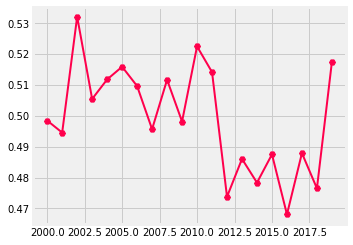

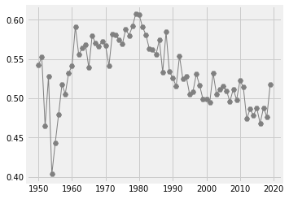

```python
years_pos = main_music.groupby('released')['positivity'].mean()
modern_pos = main_music[main_music['released'] >= 2000].groupby('released')['positivity'].mean()

plt.figure(figsize = (5, 4))
plt.plot(modern_pos.index, modern_pos, color = '#FF004C', marker = 'H', linewidth = '2', label = "Positivity-Rating in Today's Music (2000-2019)")
plt.show()

plt.figure(figsize = (5, 4))
plt.plot(years_pos.index, years_pos, color = 'gray', marker = 'H', linewidth = '1')
plt.show()
```

All-Time Positivity-Rating Median : 0.531

Today's Music Positivity-Rating Median : 0.498

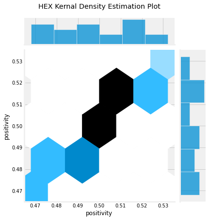

```python
sns.jointplot(x = years_pos, y = modern_pos, data = main_music, kind = 'hex')
plt.title('HEX Kernal Density Estimation Plot', y=1.25)
plt.show()
```

Hex Joint Plot

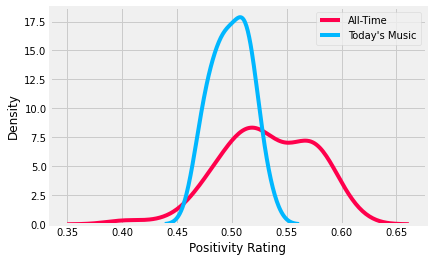

```python
sns.kdeplot(years_pos, color = '#FF004C', label = 'All-Time')
sns.kdeplot(modern_pos, color = '#00B7FF', label = "Today's Music")
plt.xlabel('Positivity Rating')
plt.legend()
plt.show()
```

Kernal Density Estimation Plot

### 3. WERE THE 60S MORE ROMANTIC THAN TODAY?

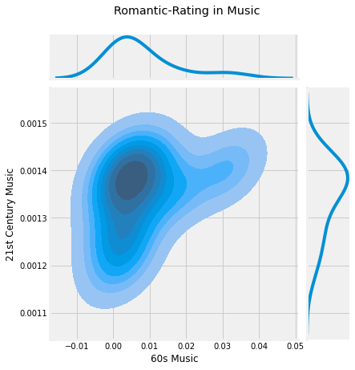

```python
sty_music =  main_music[(main_music['released'] >= 1960) & (main_music['released'] < 1970)].groupby('released')['romantic'].median()
tdy_music = main_music[main_music['released'] >= 2010].groupby('released')['romantic'].median()


kde_df = pd.DataFrame()
kde1 = sty_music.copy(deep = True)
kde1.index = [i for i in range(10)]

kde2 = tdy_music.copy(deep = True)
kde2.index = [i for i in range(10)]

kde_df['60s Music'] = kde1
kde_df['21st Century Music'] = kde2
kde_df

sns.jointplot(x = '60s Music', y = '21st Century Music', data = kde_df, kind = 'kde', shade = True)
plt.title('Romantic-Rating in Music', y = 1.27, x = -2.8)
plt.show()
```

```python
s = main_music[(main_music['released'] >= 1960) & (main_music['released'] < 1970)]
t = main_music[main_music['released'] >= 2010]

sty = s['romantic'].sort_values(ascending = False).head(1000)
tdy = t['romantic'].sort_values(ascending = False).head(1000)

sty.index = (pd.Series(np.linspace(0, 1000, num = 1000, dtype = "int")))
tdy.index = (pd.Series(np.linspace(0, 1000, num = 1000, dtype = "int")))
```

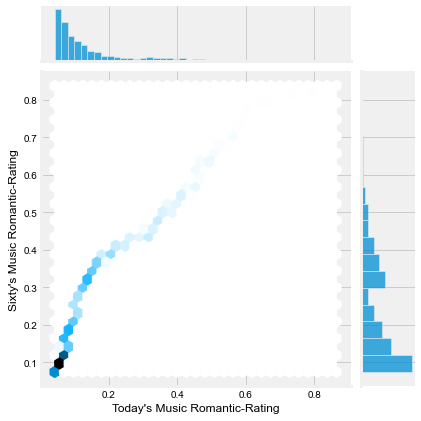

```python
sns.jointplot(x = tdy, y = sty, data = main_music, kind = 'hex')
plt.xlabel("Today's Music Romantic-Rating")
plt.ylabel("Sixty's Music Romantic-Rating")
sns.set_style('dark')
```

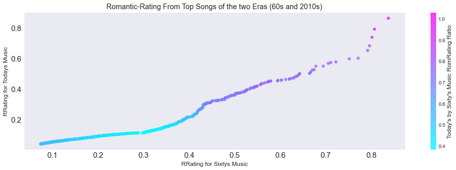

```python
plt.figure(figsize = (15, 5))

plt.scatter(sty, tdy, c = tdy/sty, cmap = 'cool', marker = 'H', alpha = 0.75)
cbar = plt.colorbar()
cbar.set_label("Today's by Sixty's Music RomRating Ratio")
plt.xlabel('RRating for Sixtys Music')
plt.ylabel('RRating for Todays Music')
plt.title('Romantic-Rating From Top Songs of the two Eras (60s and 2010s)')
plt.xticks(fontsize = '15')
plt.yticks(fontsize = '15')
plt.show()
```

### 4. IS TODAY'S MUSIC MORE VIOLENT AND OBSCENE THAN 50-60S?

(Estimator Used : Median)

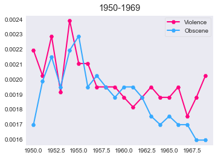

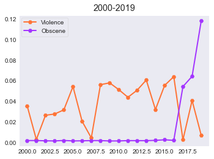

```python
old = main_music[(main_music['released'] >= 1950) & (main_music['released'] < 1970)]
new = main_music[(main_music['released'] >= 2000)]

o = old.groupby(['released'])[['violence', 'obscene']].median()
n = new.groupby(['released'])[['violence', 'obscene']].median()

plt.figure(figsize = (5, 4))
plt.plot(o.index, o.violence, label = 'Violence', color = '#FF0080', marker = 'H', linewidth = '2')
plt.plot(o.index, o.obscene, label = 'Obscene', color = '#35A9FF', marker = 'H', linewidth = '2')
plt.legend()
plt.title('1950-1969')
plt.show()


plt.figure(figsize = (5, 4))
plt.plot(n.index, n.violence, label = 'Violence', color = '#FF7335', marker = 'H', linewidth = '2')
plt.plot(n.index, n.obscene, label = 'Obscene', color = '#A335FF', marker = 'H', linewidth = '2')
plt.legend()
plt.title('2000-2019')
plt.show()
```

*Median V/O Rating (50s-60s) :

[output not shown]

*Median V/O Rating (00s-2010s) :

```
    violence    0.038296
    obscene     0.001987
```

### 5. WHICH GENRATION'S MUSIC HAD THE MOST CROWD INVOLVEMENT / STA RATING?

(Estimator Used : Mean)

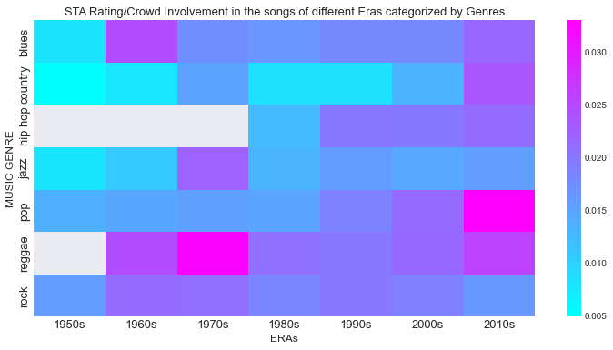

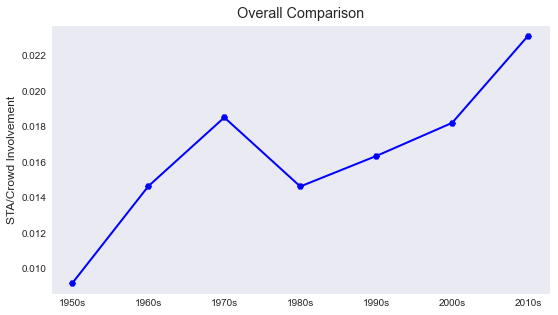

```python
gen_music = main_music.copy(deep = True)
gen_music['released'] = gen_music['released'].apply(lambda x : f"19{str(x)[2:3]}0s" if str(x)[0] == '1' else f"20{str(x)[2:3]}0s")
pvt_df = pd.DataFrame()
pvt_df['STA Rating'] = gen_music.groupby(['released', 'genre'])['shake the audience'].mean()
mtx_athand = pvt_df.pivot_table(index = 'genre', columns = 'released', values = 'STA Rating')

plt.figure(figsize = (11, 6))
sns.heatmap(mtx_athand, cmap = 'cool')
plt.ylabel('MUSIC GENRE')
plt.xlabel('ERAs')
plt.xticks(fontsize = '13')
plt.yticks(fontsize = '13')
plt.title('STA Rating/Crowd Involvement in the songs of different Eras categorized by Genres', fontsize = '13')
plt.show()

ovl = gen_music.groupby('released')['shake the audience'].mean()
plt.figure(figsize = (8, 5))
plt.plot(ovl.index, ovl, color = 'blue', marker = 'H', linewidth = '2')
plt.ylabel('STA/Crowd Involvement')
plt.title('Overall Comparison')
plt.show()
```

### 6. SEARCH FOR THE MOST SPIRITUAL & POSITIVE MUSIC GENRATION.

(Estimator Used : Mean)

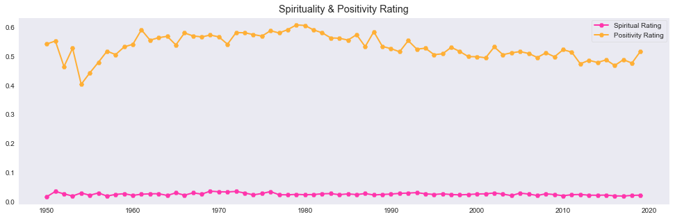

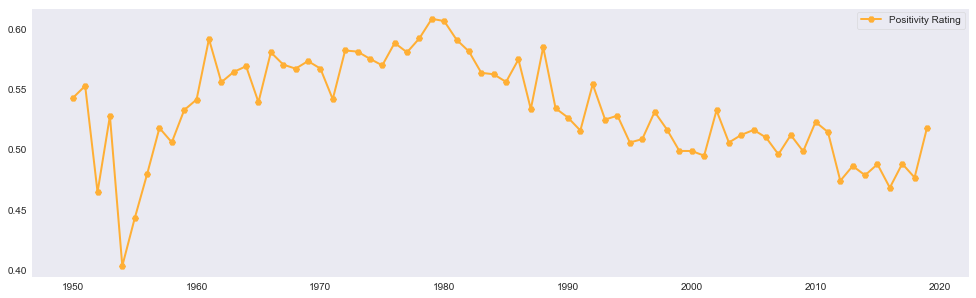

```python
snp = main_music.groupby('released')[['spiritual', 'positivity']].mean()

plt.figure(figsize = (15, 5))
plt.plot(snp.index, snp.spiritual, color = '#FF35AC', marker = 'H', label = 'Spiritual Rating', linewidth = '2')
plt.plot(snp.index, snp.positivity, color = '#FFAF35', marker = 'H', label = 'Positivity Rating', linewidth = '2')
plt.legend()
plt.title('Spirituality & Positivity Rating')
plt.show()

plt.figure(figsize = (15, 5))
plt.plot(snp.index, snp.positivity, color = '#FFAF35', marker = 'H', label = 'Positivity Rating', linewidth = '2')
plt.legend()
plt.show()
```

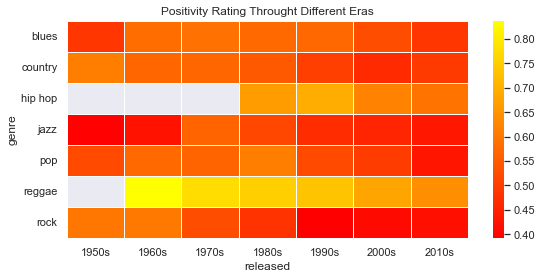

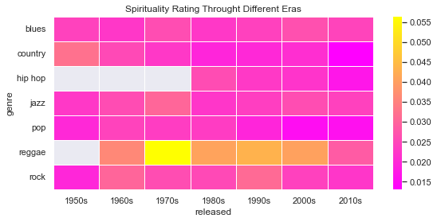

```python
pos_mx = pd.DataFrame()
pos_mx['Positivity Rating'] = gen_music.groupby(['released', 'genre'])['positivity'].mean()
pos_mx['Spiritual Rating'] = gen_music.groupby(['released', 'genre'])['spiritual'].mean()

sns.set(rc = {'figure.figsize':(8,4)})

pos_heat = pos_mx.pivot_table(index = 'genre', columns = 'released', values = 'Positivity Rating')
sns.heatmap(pos_heat, cmap = 'autumn',linecolor = 'white', linewidth = '1')
plt.title('Positivity Rating Throught Different Eras')
plt.show()

spi_heat = pos_mx.pivot_table(index = 'genre', columns = 'released', values = 'Spiritual Rating')
sns.heatmap(spi_heat, cmap = 'spring',linecolor = 'white', linewidth = '1')
plt.title('Spirituality Rating Throught Different Eras')
plt.show()
```

Note that the White Spaces indicate that genre's music missing from that particular Era, like Hip-hop Not existing from 1950 to the late 70s. All-in-All, Reggae Music has proved to be a hub of Positive & Spiritual Music, with the highest recorded Ratings in the 60s & 70s.

### 7. IS TODAY'S MUSIC MORE LOUDER THAN YESTERDAY'S?

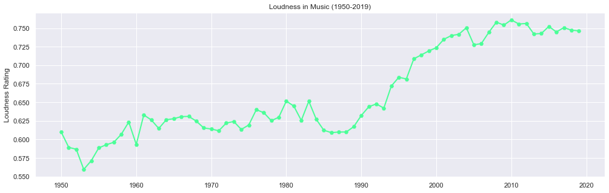

```python
year_loud = main_music.groupby('released')['loudness'].median()

plt.figure(figsize = (15, 5))
plt.plot(year_loud.index, year_loud, color = '#4AFF97', marker = 'H', linewidth = '2')
plt.ylabel("Loudness Rating")
plt.title('Loudness in Music (1950-2019)')
plt.show()
```

### 8. ANALYSIS OF SADNESS IN MODERN MUSIC :

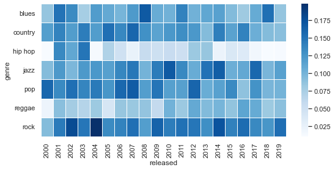

```python
new = main_music[(main_music['released'] >= 2000)]
mtx = new.pivot_table(index = 'genre', columns = 'released', values = 'sadness')
sns.heatmap(mtx, cmap = 'Blues', linecolor = 'white', linewidth = '1')
plt.show()
```

## SEGMENT - 2

### Topic : Artists Against Each Other

#### Questions & Topics to be discussed :

1. Artists with the most popular songs since the 1950s?
2. Crowd Involvement & STA Comparison : The Beatles vs Queen.
3. Who are the top artists with highest number of streaks in the Top Charts?
4. Michael Jackson vs The Weeknd.
5. Comparisons b/w Most Popular rock bands of the 60s & 70s.

### 1. ARTISTS WITH THE MOST POPULAR SONGS SINCE THE 1950s?

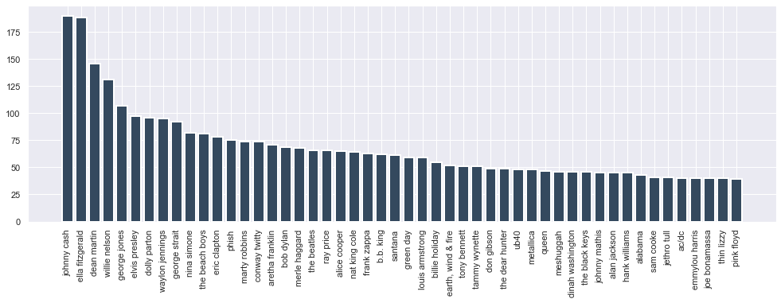

```python
top = main_music.groupby(['artist'])['title'].apply(lambda x : len(x)).sort_values(ascending = False).head(50)
plt.figure(figsize = (15, 5))
plt.bar(top.index, top, color = '#34495E', label = 'H', linewidth = '2')
plt.xticks(rotation = '90')
plt.show()
```

### 2. CROWD INVOLVEMENT & STA COMPARISON : THE BEATLES VS QUEEN

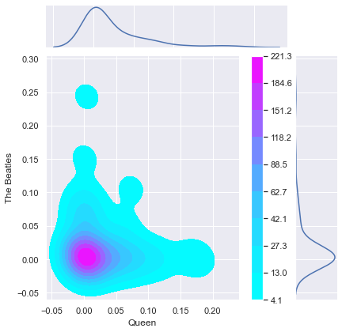

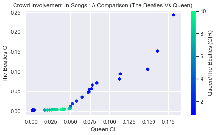

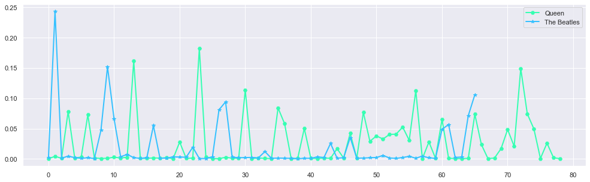

```python
queen_music = main_music[main_music['artist'].str.contains('queen')]
queen_music.index = [i for i in range(queen_music.shape[0])]

beatles_music = main_music[main_music['artist'].str.contains('beatles')]
beatles_music.index = [i for i in range(beatles_music.shape[0])]

qb_sta = pd.DataFrame()
qb_sta['Queen'] = queen_music['shake the audience']
qb_sta['The Beatles'] = beatles_music['shake the audience']
sns.jointplot(x = 'Queen', y = 'The Beatles', data = qb_sta, kind = 'kde', shade = True, cmap = 'cool', cbar = True)


q = queen_music['shake the audience'].sort_values(ascending = False).head(47)
b = beatles_music['shake the audience'].sort_values(ascending = False).head(47)
q.index = np.linspace(1, 47, num = 47, dtype = 'int')
b.index = np.linspace(1, 47, num = 47, dtype = 'int')

plt.figure(figsize = (6.4, 4))
plt.scatter(q, b, c = (q/b), cmap = 'winter', marker = 'h')
plt.xlabel('Queen CI')
plt.ylabel('The Beatles CI')
cbar = plt.colorbar()
cbar.set_label('Queen/The Beatles (CIR)')
plt.title('Crowd Involvement In Songs : A Comparison (The Beatles Vs Queen)')
plt.show()

plt.figure(figsize = (15, 5))
plt.plot(qb_sta.index, qb_sta['Queen'], linewidth = '2', marker = 'H', color = '#35FFB2', label = 'Queen')
plt.plot(qb_sta.index, qb_sta['The Beatles'], linewidth = '2', marker = '*', color = '#35C1FF', label = 'The Beatles')
plt.legend()
plt.show()
```

### WHO ARE THE TOP ARTISTS WITH HIGHEST NUMBER OF STREAKS IN THE TOP CHARTS?

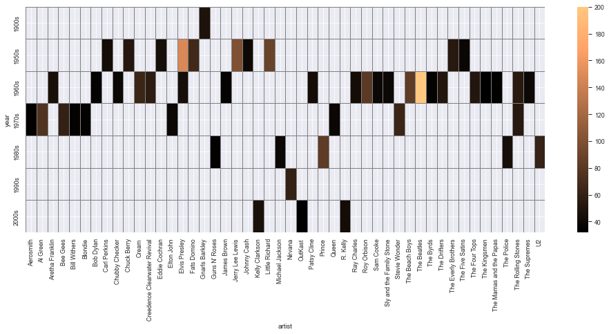

```python
w500 = top500.copy(deep = True)
import numpy as np
w500.dropna(inplace = True)
w500['streakn'] = w500['streak'].apply(lambda x : int("".join([str(_) for _ in x.split() if _.isdigit()])) if "".join([str(_) for _ in x.split() if _.isdigit()]) != "" else np.nan)

astrk = pd.DataFrame()
astrk['Weeks'] = w500.groupby('artist')['streakn'].sum()

w500['year'] = w500['released'].apply(lambda x : f"19{x[-2:-1]}0s" if x.split()[-1][0] == '1' else f"20{x[-2:-1]}0s")


astrk = pd.DataFrame()
astrk['Weeks'] = w500.groupby(['artist', 'year'])['streakn'].sum()
sns.set(rc = {'figure.figsize' : (15, 6)})
sns.set_context('paper')
strk_pvt = astrk.sort_values(by = 'Weeks', ascending = False).head(50).pivot_table(index = 'year', columns = 'artist', values = 'Weeks')
sns.heatmap(strk_pvt, cmap = 'copper',linecolor = 'gray', linewidth = '1')
plt.grid()
plt.show()
```

THE BEATLES, ELVIS PRESLEY & JERRY LEE LEWIS are some of the names that dominated the top charts for hundreds of weeks

```
    The Beatles 1960s   200.0 Weeks
    Elvis Presley   1950s   147.0 Weeks
    Jerry Lee Lewis 1950s   100.0 Weeks
```

### 4. MICHAEL JACKSON VS THE WEEKND.

```
[]
```

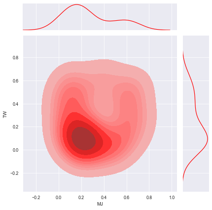

```python
mj_music = main_music[main_music['artist'] == 'michael jackson']
wk_music = main_music[main_music['artist'] == 'the weeknd']

rm_joint = pd.DataFrame()
mj_music["acoustic"].index = [i for i in range(31)]
wk_music["acoustic"].index = [i for i in range(19)]

rm_joint['MJ'] = mj_music["acoustic"]
rm_joint['TW'] = wk_music["acoustic"]

sns.jointplot(x = 'MJ', y = 'TW', color = 'Red', data = rm_joint, kind = 'kde', shade = True)
plt.plot()
```

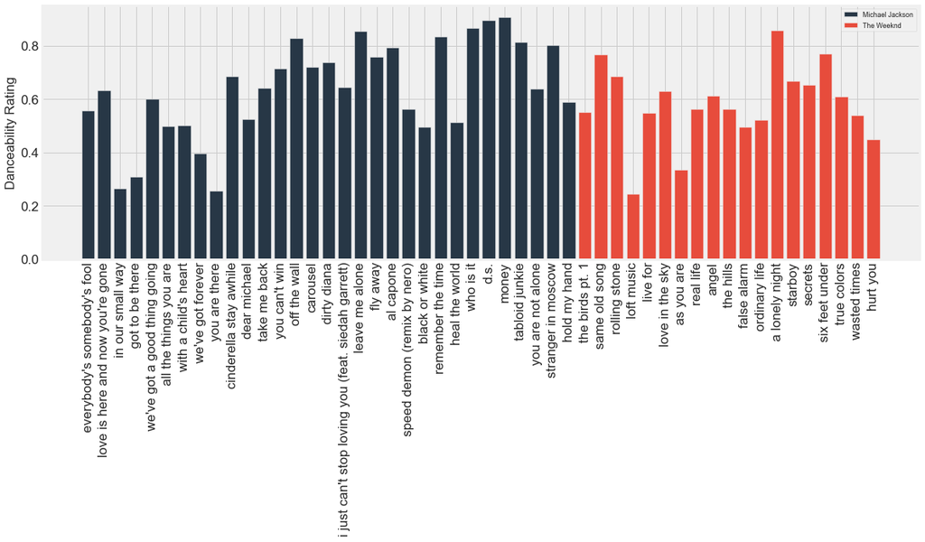

```python
plt.figure(figsize = (18, 6))
plt.style.use('fivethirtyeight')
plt.bar(mj_music['title'], mj_music['danceability'], color = '#273746', label = 'Michael Jackson')
plt.bar(wk_music['title'], wk_music['danceability'], color = '#E74C3C', label = 'The Weeknd')
plt.legend()
plt.xticks(rotation = '90', fontsize = '17')
plt.ylabel('Danceability Rating')
plt.yticks(fontsize = '17')
plt.show()
```

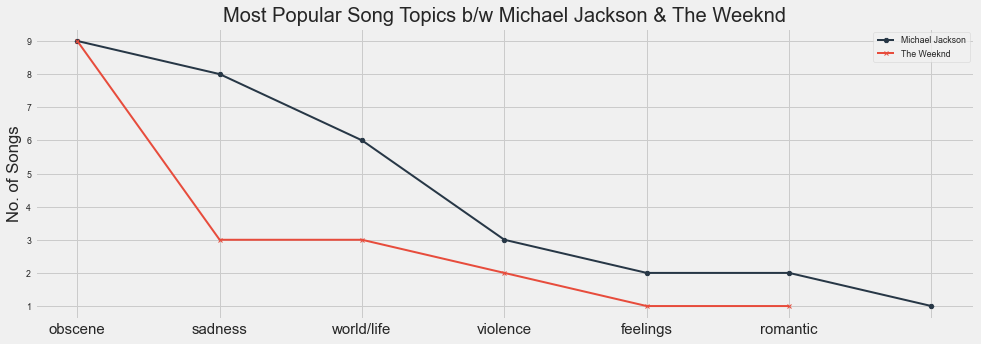

```python
plt.figure(figsize = (15, 5))
plt.style.use('fivethirtyeight')
mj_music['topic'].value_counts().plot(color = '#273746', label = 'Michael Jackson', linewidth = '2', marker = 'H')
wk_music['topic'].value_counts().plot(color = '#E74C3C', label = 'The Weeknd', linewidth = '2', marker = 'x')
plt.legend()
plt.xticks(fontsize = '15')
plt.ylabel('No. of Songs')
plt.title('Most Popular Song Topics b/w Michael Jackson & The Weeknd')
plt.show()
```

### COMPARISONS B/W MOST POPULAR ROCK BANDS OF THE 60s & 70s.

(Estimator Used : Mean)

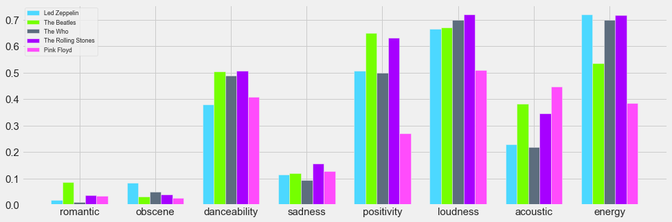

```python
lz = main_music[main_music['artist'] == 'led zeppelin']
tb = main_music[main_music['artist'] == 'the beatles']
tw = main_music[main_music['artist'] == 'the who']
rs = main_music[main_music['artist'] == 'the rolling stones']
pf = main_music[main_music['artist'] == 'pink floyd']


a = lz.groupby('artist')['romantic', 'obscene', 'danceability', 'sadness', 'positivity', 'loudness', 'acoustic', 'energy'].mean().iloc[0]
b = tb.groupby('artist')['romantic', 'obscene', 'danceability', 'sadness', 'positivity', 'loudness', 'acoustic', 'energy'].mean().iloc[0]
c = tw.groupby('artist')['romantic', 'obscene', 'danceability', 'sadness', 'positivity', 'loudness', 'acoustic', 'energy'].mean().iloc[0]
d = rs.groupby('artist')['romantic', 'obscene', 'danceability', 'sadness', 'positivity', 'loudness', 'acoustic', 'energy'].mean().iloc[0]
e = pf.groupby('artist')['romantic', 'obscene', 'danceability', 'sadness', 'positivity', 'loudness', 'acoustic', 'energy'].mean().iloc[0]

x_ind = np.arange(len(a))
w = 0.15

plt.figure(figsize = (15, 5))
plt.bar(x_ind-2*w, a, width = w, color = '#4CD8FF', label = 'Led Zeppelin')
plt.bar(x_ind-w, b, width = w, color = '#75FF00', label = 'The Beatles')
plt.bar(x_ind, c, width = w, color = '#5D6D7E', label = 'The Who')
plt.bar(x_ind+w, d, width = w, color = '#A700FF', label = 'The Rolling Stones')
plt.bar(x_ind+2*w, e, width = w, color = '#FF4CFC', label = 'Pink Floyd')


plt.xticks(ticks = x_ind, labels = a.index)
plt.legend(fontsize = '15')
plt.xticks(fontsize = '15')
plt.yticks(fontsize = '15')
plt.legend()
plt.show()
```

## SEGMENT - 3

### Topic : Playing with Statistics

#### Questions & Topics to be discussed :

1. Which Era had the longest song titles ever?
2. Which Starting Letters are most commonly used for Sad Songs?
3. Which Era & Genre of Music usually contributes to the most lengthy lyrics?
4. Are Romantic songs more lengthy than on Average?

### 1. WHICH ERA HAD THE LONGEST SONG TITLES EVER?

(Estimator Used : Mean)

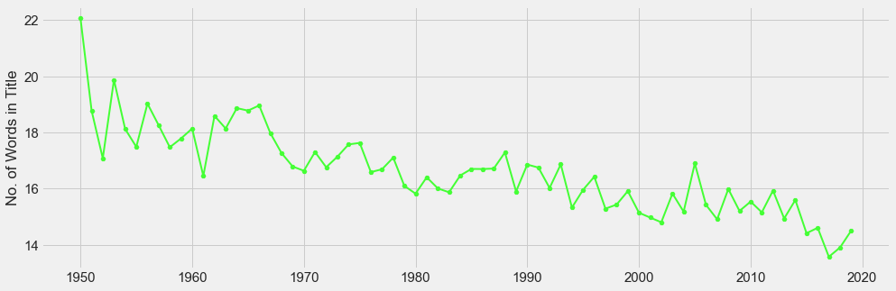

```python
eti = main_music.groupby('released')['title_length'].mean()

plt.figure(figsize = (15, 5))
plt.style.use('fivethirtyeight')
plt.plot(eti.index, eti, color = '#44FF35', linewidth = '2', marker = 'H')
plt.xticks(fontsize = '15')
plt.yticks(fontsize = '15')
plt.ylabel('No. of Words in Title')
plt.show()
```

Titles for Songs used to be excessively long in the 1950s, and quite the opposite as of late. There has been a steady decline throughout the curve with a few ups and downs here and there.

### 2. WHICH STARTING LETTERS ARE MOST COMMONLY USED FOR SAD SONGS?

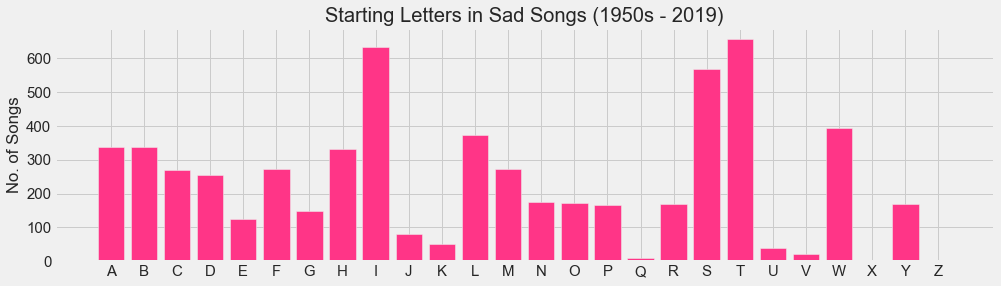

```python
sad_songs = main_music[main_music['topic'] == 'sadness']
sad_songs['title'] = sad_songs['title'].apply(lambda x : x[:1].upper() if x[:1] in string.ascii_letters else np.nan)
sad_songs.dropna(inplace = True)

plt.figure(figsize = (15, 4))
plt.bar([x for x in string.ascii_uppercase], sad_songs['title'].value_counts().sort_index(), color = '#FF3587')
plt.xticks(fontsize = '15')
plt.ylabel('No. of Songs')
plt.yticks(fontsize = '15')
plt.title('Starting Letters in Sad Songs (1950s - 2019)')
plt.show()
```

### 3. WHICH ERA & GENRE OF MUSIC USUALLY CONTRIBUTES TO THE MOST LENGTHY LYRICS?

(Estimator Used : Median)

```
[]
```

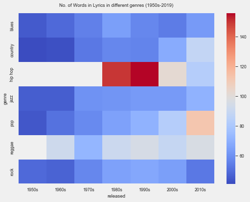

```python
slendf = pd.DataFrame()
slendf['No. of Words in Lyrics'] = gen_music.groupby(['released', 'genre'])['song_length'].median()

slen_pvt = slendf.pivot_table(index = 'genre', columns = 'released', values = 'No. of Words in Lyrics')

plt.figure(figsize = (8, 6))
plt.style.use('fivethirtyeight')
sns.set_context('paper')
sns.heatmap(slen_pvt, cmap = 'coolwarm', cbar = True)
plt.title('No. of Words in Lyrics in different genres (1950s-2019)', y = 1.02)
plt.plot()
```

### 4. ARE ROMANTIC SONGS MORE LENGTHY THAN ON AVERAGE?

(Estimator Used : Median)

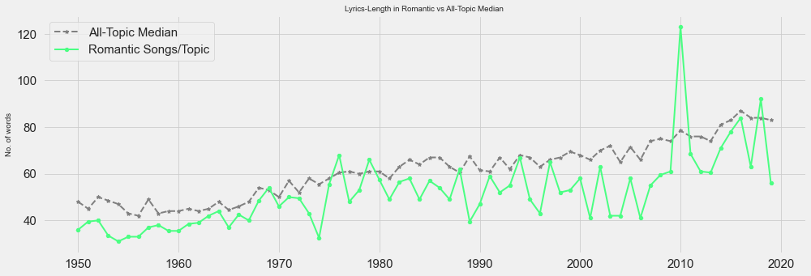

```python
romantic = main_music[main_music['topic'] == 'romantic']
rs = romantic.groupby('released')['song_length'].median()
year_wise_lyrics = main_music.groupby('released')['song_length'].median()


plt.figure(figsize =(15, 5))
plt.plot(year_wise_lyrics.index, year_wise_lyrics, linestyle = '--' ,color = 'gray', marker = '*', linewidth = '2', label = 'All-Topic Median')
plt.plot(rs.index, rs, color = '#4AFF82', linewidth = '2', marker = 'H', label = 'Romantic Songs/Topic')
plt.legend(fontsize = '15')
plt.xticks(fontsize = '15')
plt.yticks(fontsize = '15')
plt.title('Lyrics-Length in Romantic vs All-Topic Median')
plt.ylabel('No. of words')

plt.show()
```

### CITATIONS & REFERENCES

Datsets Used in this Analysis ;

1. 1950-2019 Critics Rated Music Dataset can be found here, https://www.kaggle.com/saurabhshahane/music-dataset-1950-to-2019
2. Top 500 Songs Dataset is available here, https://www.kaggle.com/omarhanyy/500-greatest-songs-of-all-time